# PSpecteR Manual Version 2.0.0

David J. Degnan, Lisa M. Bramer, Amanda M. White, Mowei Zhou, Aivett Bilbao, Lee Ann McCue

2023-04-20

# 1 PSpecteR Description

## 1.1 Abstract

Visual examination of mass spectrometry data is necessary to assess data quality and to facilitate data exploration. Graphics provide the means to evaluate spectral properties, test alternative peptide/protein sequence matches, prepare annotated spectra for publication, and fine-tune parameters during wet lab procedures. Visual inspection of LC-MS data is hindered by proteomics visualization software designed for particular workflows (e.g. bottom-up or top-down analyses; support for ThermoFisher raw files or XML-based, etc.) or vendor specific tools without open-source code. We built PSpecteR, an open-source and interactive R Shiny web application to address these issues, with support for several steps of proteomics data processing, including: reading various mass spectrometry files, running open-source database search engines, labelling spectra with fragmentation patterns, testing post-translational modifications, plotting where identified fragments map to reference sequences, and visualizing algorithmic output and metadata. All figures, tables, and spectra are exportable within one easy-to-use graphical user interface. Our current software provides a flexible and modern R framework to support fast implementation of additional features. The open-source code is readily available (https://github.com/EMSL-Computing/PSpecteR), and a PSpecteR Docker container (https://hub.docker.com/r/emslcomputing/pspecter) is available for easy local installation.

## 1.2 Version Explanations

There are two version of PSpecteR:

**PSpecteR**: The full version of the application which includes the ability to run MS-GF+ and MSPathFinder.

**PSpecteR Light:** A simpler version of the application which does not include MS-GF+ and MSPathFinder.

## 1.3 Module Descriptions

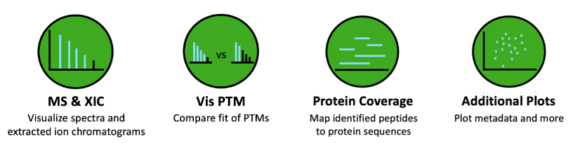

**Upload Data:** Upload either an XML-based (.mzML, .mzXML) MS file, or a ThermoFisher (.raw) file. For identification data, currently only mzid data is supported. FASTA files are optional. Example datasets are included within the application.

**MS & XIC:** Visualize peptide and protein identifications overlayed on experimental mass spectra data. Extracted ion chromatograms are also calculated and visualized.

**Test and Visualize PTMs:** Use ProForma strings to test the fit of alternative proteoforms. There are widgets and shorthand options to test multiple modifications quickly. Any unique modifications can be added in the glossary.

**Protein Coverage:** Visualize where identified peptides overlay on protein sequences.

**Additional Plots:** There are 2 available plots - plotting metadata, and ProMex (part of the MSPathFinder suite) feature identification data.

# 2 Upload Data

This page allows the user to upload:

- A required mass spectrometry file (MS): mzML, mzXML, or Thermo Fisher raw
- An optional protein ID file (ID): mzid
- An optional protein database file (FA): fasta

You may also choose the test files at the bottom of the “Upload Data” page. There is also a description mode with pop-ups that we suggest new users try out.

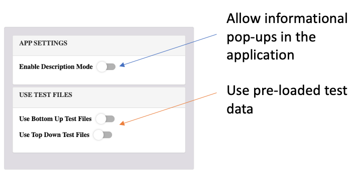

```r
knitr::include_graphics("DescriptionsAndData.png")
```